# NFL_Analysis

## Introduction

We’re going to do some basic analysis on NFL teams from 2002-2020. This consists of the 16-game-per-season era since the league has had 32 teams.

Let’s import some important libraries.

```r
library(tidyverse)
```

```r
library(ggplot2)
```

The dataset was built up in Google Sheets from “nfl.com/standings” (link to the sheet will be attached below). It was then downloaded as a TSV and imported using the handy read_tsv function (make sure to set the correct working directory!).

Link to the sheet to download dataset: https://docs.google.com/spreadsheets/d/1mVI7F5M91gVVnUujeiHs3yJvKrY6W4t4vTfcdIaFoOg/edit?usp=sharing

```r
df <- read_tsv('NFLData.tsv')
```

First, we will conduct some exploration and try to understand the dataset. Then, we will explore the relationship of points. We’ll explore points scored, points allowed, and point differential versus wins. Obviously, for individual games, measurements like point differential are highly correlated with wins, but over the average course of a season we might see different results.

Note: After the analysis, it makes more sense to plot winning percentage (wins + 0.5 * ties). Overall the graphs should still look the same.

## Data analysis

Let’s first get a look of what’s in our data!

```r
names(df)
```

```
##  [1] "year"    "team"    "wins"    "losses"  "ties"    "pct"     "forced"
##  [8] "allowed" "net"     "homeW"   "homeL"   "roadW"   "roadL"
```

```r
summary(df)
```

```
##       year          team                wins            losses
##  Min.   :2002   Length:608         Min.   : 0.000   Min.   : 0.000
##  1st Qu.:2006   Class :character   1st Qu.: 6.000   1st Qu.: 6.000
##  Median :2011   Mode  :character   Median : 8.000   Median : 8.000
##  Mean   :2011                      Mean   : 7.982   Mean   : 7.982
##  3rd Qu.:2016                      3rd Qu.:10.000   3rd Qu.:10.000
##  Max.   :2020                      Max.   :16.000   Max.   :16.000
##       ties              pct             forced         allowed
##  Min.   :0.00000   Min.   :0.0000   Min.   :168.0   Min.   :196.0
##  1st Qu.:0.00000   1st Qu.:0.3750   1st Qu.:301.8   1st Qu.:313.8
##  Median :0.00000   Median :0.5000   Median :355.0   Median :350.5
##  Mean   :0.03618   Mean   :0.4989   Mean   :355.1   Mean   :355.1
##  3rd Qu.:0.00000   3rd Qu.:0.6250   3rd Qu.:402.0   3rd Qu.:395.0
##  Max.   :1.00000   Max.   :1.0000   Max.   :606.0   Max.   :519.0
##       net              homeW           homeL           roadW
##  Min.   :-261.00   Min.   :0.000   Min.   :0.000   Min.   :0.000
##  1st Qu.: -75.00   1st Qu.:3.000   1st Qu.:2.000   1st Qu.:2.000
##  Median :   1.50   Median :5.000   Median :3.000   Median :3.000
##  Mean   :   0.00   Mean   :4.526   Mean   :3.472   Mean   :3.459
##  3rd Qu.:  74.25   3rd Qu.:6.000   3rd Qu.:5.000   3rd Qu.:5.000
##  Max.   : 315.00   Max.   :8.000   Max.   :8.000   Max.   :8.000
##      roadL
##  Min.   :0.000
##  1st Qu.:3.000
##  Median :5.000
##  Mean   :4.521
##  3rd Qu.:6.000
##  Max.   :8.000
```

```r
head(df)
```

```
## # A tibble: 6 x 13
##    year team      wins losses  ties   pct forced allowed   net homeW homeL roadW
##   <dbl> <chr>    <dbl>  <dbl> <dbl> <dbl>  <dbl>   <dbl> <dbl> <dbl> <dbl> <dbl>
## 1  2020 Seattle…    12      4     0 0.75     459     371    88     7     1     5
## 2  2020 Los Ang…    10      6     0 0.625    372     296    76     6     2     4
## 3  2020 Arizona…     8      8     0 0.5      410     367    43     4     4     4
## 4  2020 San Fra…     6     10     0 0.375    376     390   -14     1     7     5
## 5  2020 New Orl…    12      4     0 0.75     482     337   145     6     2     6
## 6  2020 Tampa B…    11      5     0 0.688    492     355   137     5     3     6
## # … with 1 more variable: roadL <dbl>
```

There are 32 teams in the NFL, and 19 years in this dataset. Let’s create an aggregated dataset where we combine all of a teams stats.

```r
combined_df <- df %>%
  group_by(team) %>%
  summarise(wins = sum(wins), losses = sum(losses), ties = sum(ties),
            scored = sum(forced),
            allowed = sum(allowed),
            net = sum(net)) %>%
  mutate(pct = (wins + 0.5 * ties) / (wins + losses + ties))
print(combined_df)
```

```
## # A tibble: 32 x 8
##    team                wins losses  ties scored allowed   net   pct
##    <chr>              <dbl>  <dbl> <dbl>  <dbl>   <dbl> <dbl> <dbl>
##  1 Arizona Cardinals    135    167     2   6340    7149  -809 0.447
##  2 Atlanta Falcons      157    146     1   7089    6905   184 0.518
##  3 Baltimore Ravens     179    125     0   7009    5723  1286 0.589
##  4 Buffalo Bills        139    165     0   6279    6735  -456 0.457
##  5 Carolina Panthers    154    149     1   6557    6599   -42 0.508
##  6 Chicago Bears        147    157     0   6295    6477  -182 0.484
##  7 Cincinnati Bengals   139    161     4   6526    6862  -336 0.464
##  8 Cleveland Browns     100    203     1   5499    7044 -1545 0.331
##  9 Dallas Cowboys       164    140     0   6990    6689   301 0.539
## 10 Denver Broncos       168    136     0   7017    6682   335 0.553
## # … with 22 more rows
```

Note: We chose to sum up all the data and then added a column for the win percentage across the 19 seasons.

Alright, now it’s time to do some very basic plotting. Let’s just look at scored vs percentage in the original data.

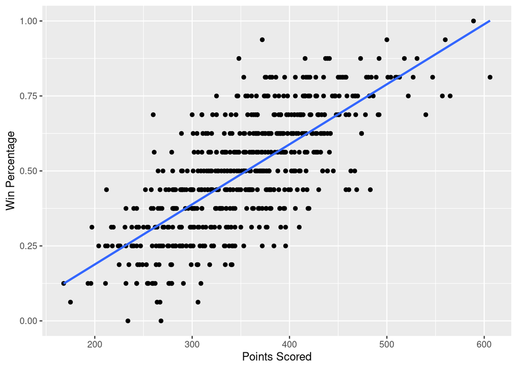

```r
ggplot(data=df, aes(x = forced, y = pct)) + geom_point() +
  geom_smooth(formula = y ~ x, method = "lm", se = FALSE) +
  labs(x = "Points Scored", y = "Win Percentage")
```

Very interesting. For the most part, of course we see a direct positive correlation. The more you score, the more you win, right? But what about the line on the left, which essentially has a bunch of super low scoring teams. Let’s go ahead and split by year.

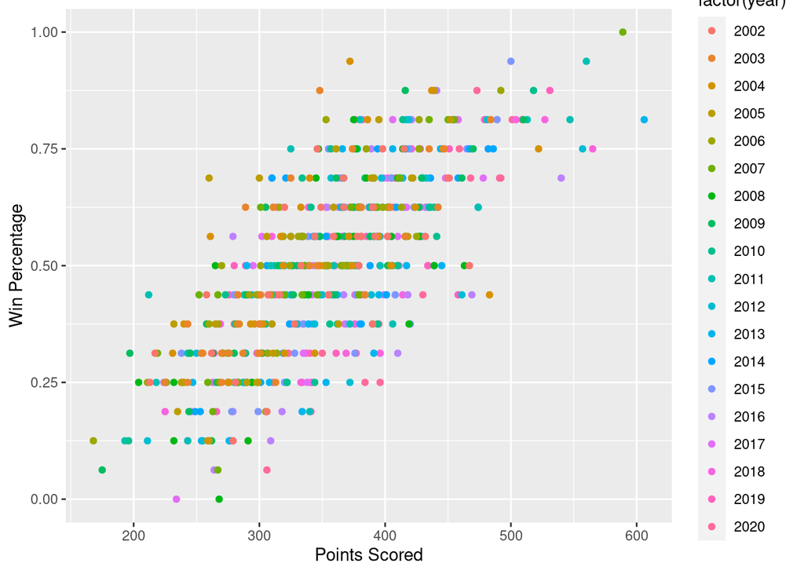

```r
ggplot(data=df, aes(x = forced, y = pct, color=factor(year))) + geom_point() +
  labs(x = "Points Scored", y = "Win Percentage")
```

Okay, the colors are confusing. Let’s plot from 2016 onward to see if we can notice anything interesting.

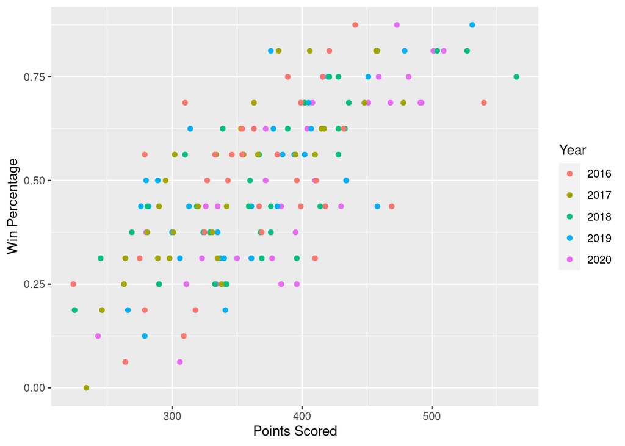

```r
df_2016_plus <- subset(df, df$year >= 2016)
ggplot(data=df_2016_plus, aes(x = forced, y = pct, color=factor(year))) + geom_point() +
  labs(x = "Points Scored", y = "Win Percentage") +
  guides(col = guide_legend("Year"))
```

Now let’s go ahead and plot points forced, allowed, and net vs win percentage for our data.

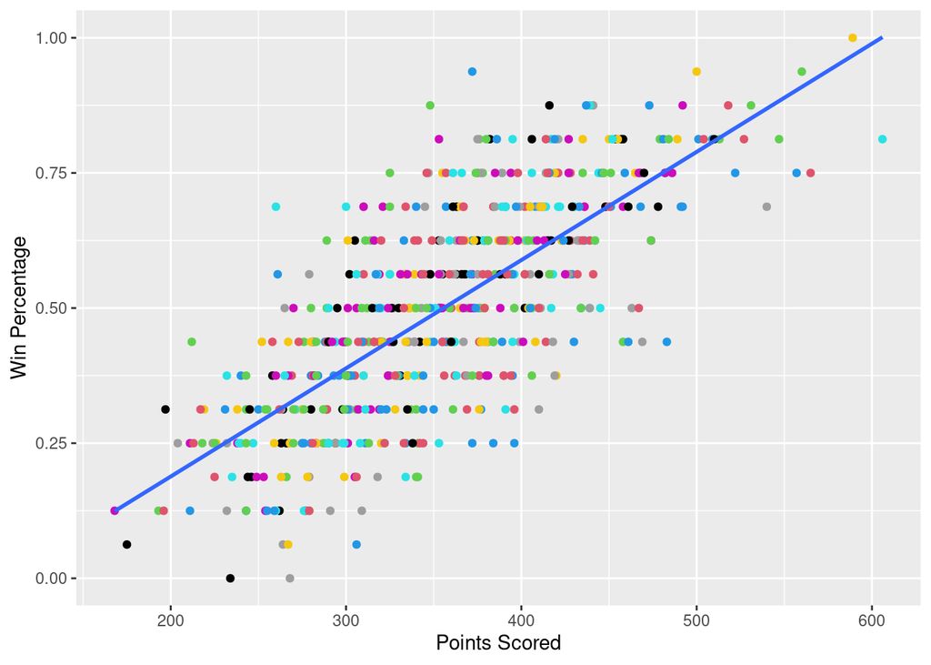

```r
ggplot(data=df, aes(x=forced, y=pct)) + geom_point(color=factor(df$year)) +
  geom_smooth(formula = y ~ x, method = "lm", se = FALSE) +
  labs(x = "Points Scored", y = "Win Percentage")
```

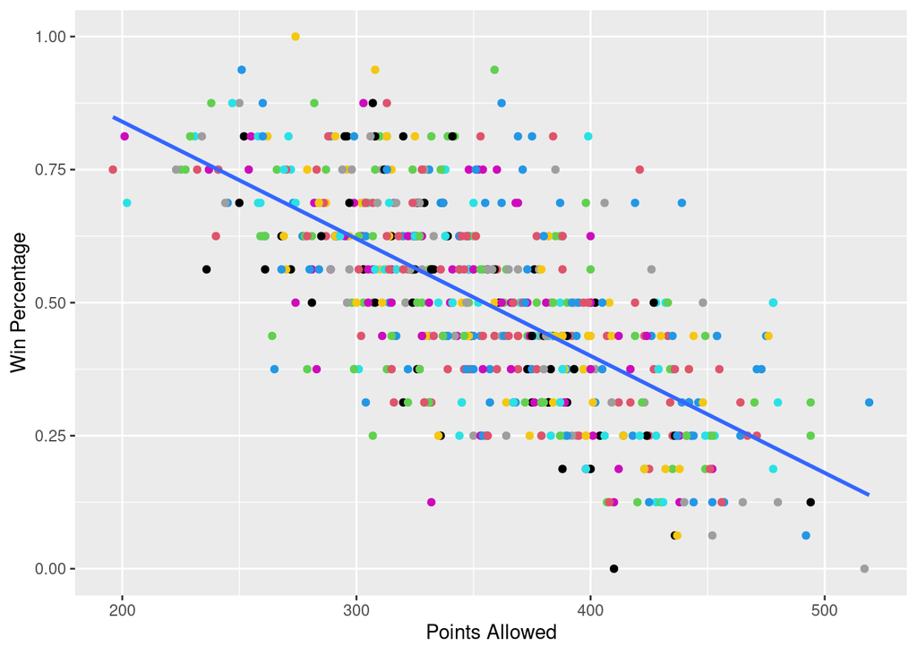

```r
ggplot(data=df, aes(x=allowed, y=pct)) + geom_point(color=factor(df$year)) +
  geom_smooth(formula = y ~ x, method = "lm", se = FALSE) +
  labs(x = "Points Allowed", y = "Win Percentage")
```

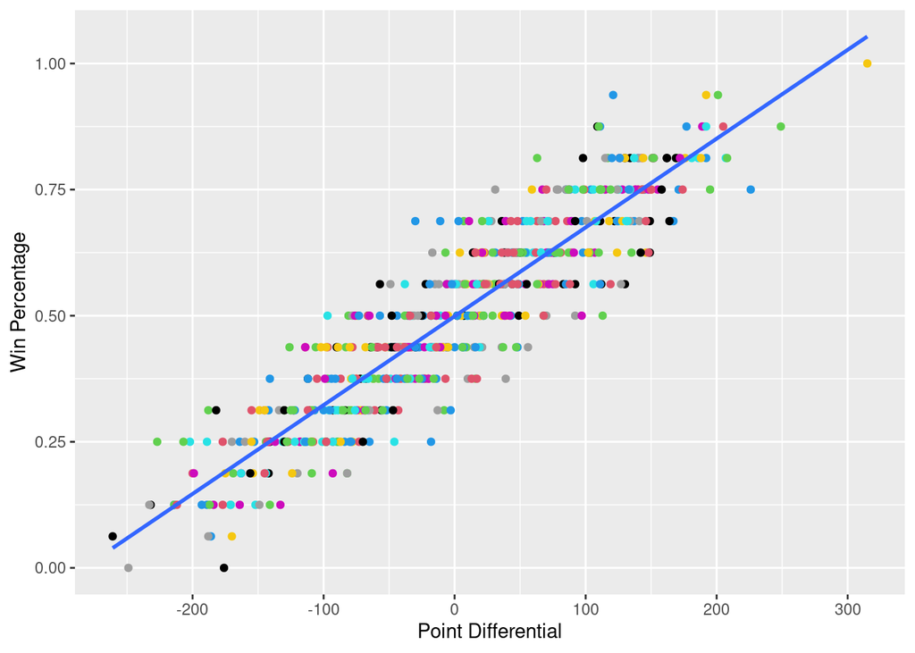

```r
ggplot(data=df, aes(x=net, y=pct)) + geom_point(color=factor(df$year)) +
  geom_smooth(formula = y ~ x, method = "lm", se = FALSE) +
  labs(x = "Point Differential", y = "Win Percentage")
```

Honestly, just as expected. There is a strong correlation between scored points, allowed points, and an extremely strong correlation for net points. Let’s calculate the correlation exactly.

```r
print(cor(x=df$forced, y=df$pct))
```

```
## [1] 0.7394541
```

```r
print(cor(x=df$allowed, y=df$pct))
```

```
## [1] -0.6661064
```

```r
print(cor(x=df$net, y=df$pct))
```

```
## [1] 0.9143313
```

Interestingly enough, defense is not as correlated. There’s too many dots on these graphs, and labeling would be a visual nightmare. Let’s switch over to the combined datasets. Let’s look at the generic plots before answering/asking any questions.

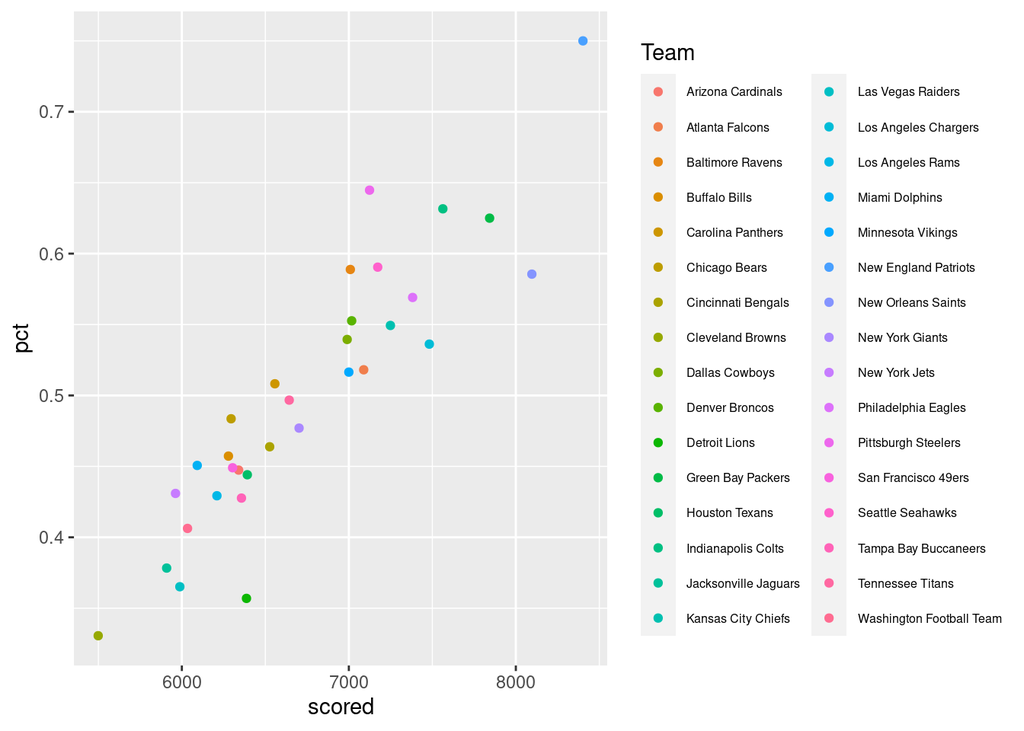

```r
ggplot(data=combined_df, aes(x=scored, y=pct, color = team)) + geom_point() +
  guides(col = guide_legend("Team")) +
  theme(legend.text = element_text(size = 6))
```

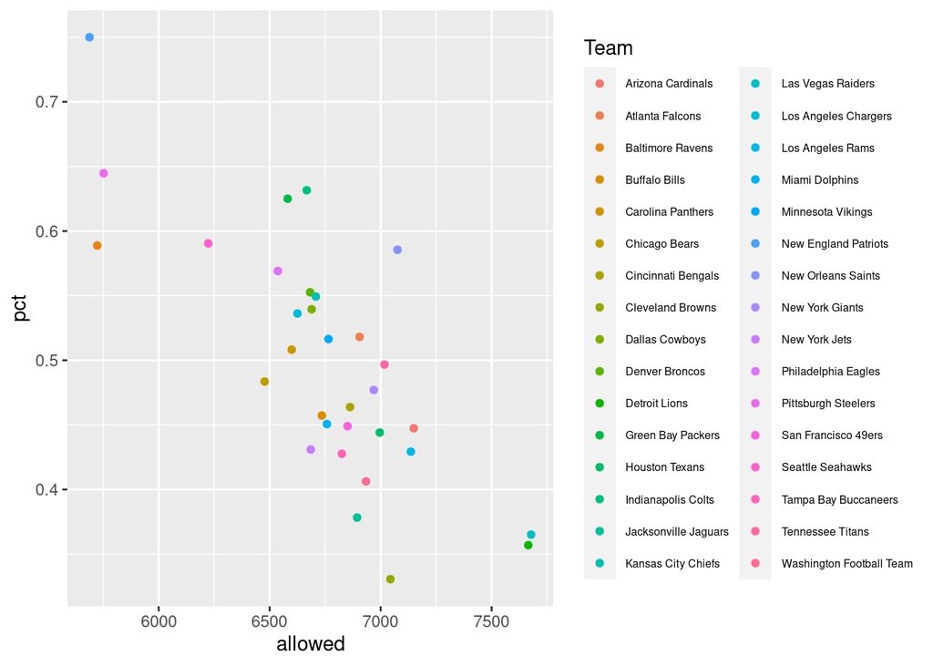

```r
ggplot(data=combined_df, aes(x=allowed, y=pct, color = team)) + geom_point() +
  guides(col = guide_legend("Team")) +
  theme(legend.text = element_text(size = 6))
```

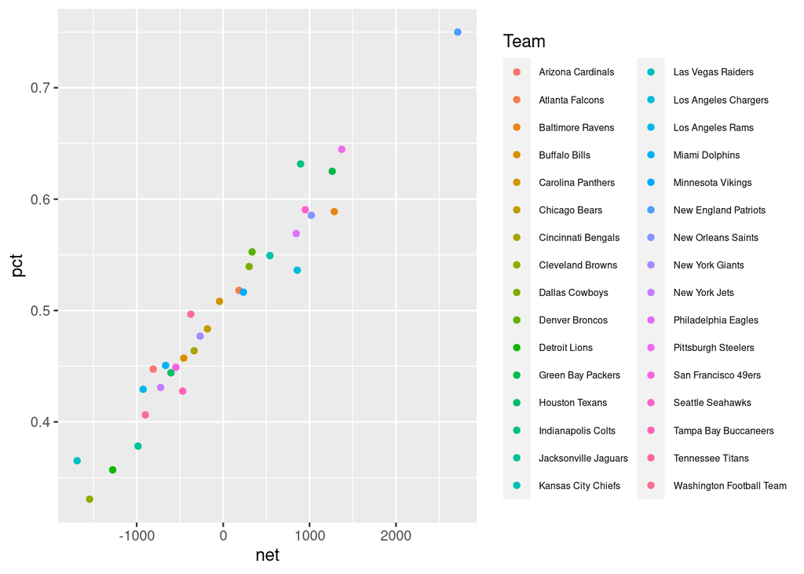

```r
ggplot(data=combined_df, aes(x=net, y=pct, color = team)) + geom_point() +
  guides(col = guide_legend("Team")) +
  theme(legend.text = element_text(size = 6))
```

Once again we see strong correlations. Let’s also once again calculate the correlations exactly.

```r
print(cor(x=combined_df$scored, y=combined_df$pct))
```

```
## [1] 0.9119221
```

```r
print(cor(x=combined_df$allowed, y=combined_df$pct))
```

```
## [1] -0.7643602
```

```r
print(cor(x=combined_df$net, y=combined_df$pct))
```

```
## [1] 0.977903
```

Even stronger correlations then before. It is again interesting to note that points allowed is quite weaker as a correlation.

Finally, we want to see who wont the most and who lost the most.

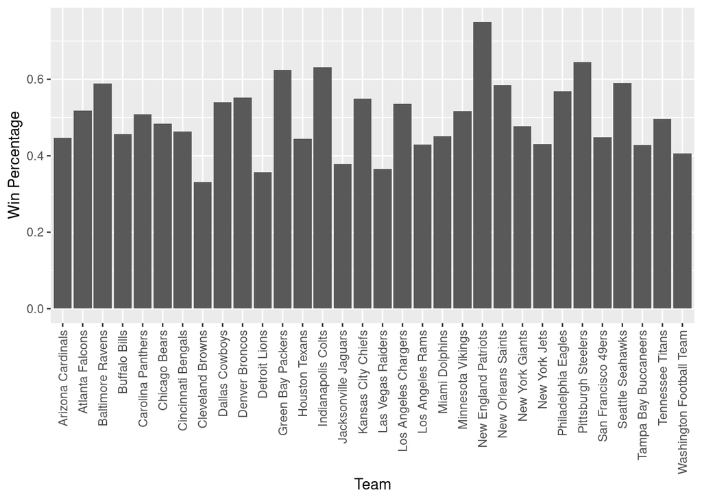

```r
ggplot(data=combined_df, aes(x=team, y=pct)) + geom_col() +
  theme(axis.text.x = element_text(angle = 90, vjust=0.5, hjust=1)) +
  labs(x="Team", y="Win Percentage")
```

## Conclusion

The team with the highest win percentage across the 19 years of our dataset was the New England Patriots. This is not surprising at all as the Patriots have been considered the NFL’s dynasty in the last 2 decades as they have won 6 Superbowls since 2001. Also, not surprisingly, they had the highest point differential. Their point differential was over 1000 points higher than the next team. On the contrary, the Cleveland Browns had the lowest win percentage across the 19 years of our dataset. This is also not surprising as the Browns were mediocre at best in the NFL over the last 2 decades. The Browns, in 2017, become the 2nd team in NFL history to have a 0 win, 16 loss season (the other was the Detroit Lions in 2008). Shockingly though, the Browns did not have the worst point differential (they had the second worst). The Las Vegas Raiders beat out the Browns for worst Point Differential by over 100 points (and the had the 3rd lowest win percentage).

What did our analysis find? Overall, we got some very obvious results but it’s nice to see the clear visualizations and a confirmation of our beliefs. The one major interesting insight that we found was that defense (points allowed) was not as indicative of winrate compared to offense (points scored). Offense was at around the middle, while net points was very strongly correlated with winning.

In summary: scoring more points in a football game than the other team helps you win.